# Better Data Analysis with R

## Introduction to DataFrames Tutorial-2

## What is a Data Frame?

A Data Frame in R is a special way of representing tabular data within a signle variable. It has the added benefit of allowing us to access columns by name and filtering data based on values.

## Using Data Frames

R comes in with some built in datasets. Let’s open up the mtcars dataset which contains information about some cars rated by MotorTrend Magazine in the 1970’s.

```r
#load the data set
data(mtcars)

#you can access the dataset via mtcars but let's assign it to a variable to view some of the data
cars <- mtcars
```

If you look in your environment window, you will notice a variable Data variable named cars. It should have 32 observations with 11 variables. Click on cars to view the mtcars data. Alternatively, we can view the data by typing ‘cars’ (no quotes) into the R Console.

```r
cars
```

```
##                      mpg cyl  disp  hp drat    wt  qsec vs am gear carb
## Mazda RX4           21.0   6 160.0 110 3.90 2.620 16.46  0  1    4    4
## Mazda RX4 Wag       21.0   6 160.0 110 3.90 2.875 17.02  0  1    4    4
## Datsun 710          22.8   4 108.0  93 3.85 2.320 18.61  1  1    4    1
## Hornet 4 Drive      21.4   6 258.0 110 3.08 3.215 19.44  1  0    3    1
## Hornet Sportabout   18.7   8 360.0 175 3.15 3.440 17.02  0  0    3    2
## Valiant             18.1   6 225.0 105 2.76 3.460 20.22  1  0    3    1
## Duster 360          14.3   8 360.0 245 3.21 3.570 15.84  0  0    3    4
## Merc 240D           24.4   4 146.7  62 3.69 3.190 20.00  1  0    4    2
## Merc 230            22.8   4 140.8  95 3.92 3.150 22.90  1  0    4    2
## Merc 280            19.2   6 167.6 123 3.92 3.440 18.30  1  0    4    4
## Merc 280C           17.8   6 167.6 123 3.92 3.440 18.90  1  0    4    4
## Merc 450SE          16.4   8 275.8 180 3.07 4.070 17.40  0  0    3    3
## Merc 450SL          17.3   8 275.8 180 3.07 3.730 17.60  0  0    3    3
## Merc 450SLC         15.2   8 275.8 180 3.07 3.780 18.00  0  0    3    3
## Cadillac Fleetwood  10.4   8 472.0 205 2.93 5.250 17.98  0  0    3    4
## Lincoln Continental 10.4   8 460.0 215 3.00 5.424 17.82  0  0    3    4
## Chrysler Imperial   14.7   8 440.0 230 3.23 5.345 17.42  0  0    3    4
## Fiat 128            32.4   4  78.7  66 4.08 2.200 19.47  1  1    4    1
## Honda Civic         30.4   4  75.7  52 4.93 1.615 18.52  1  1    4    2
## Toyota Corolla      33.9   4  71.1  65 4.22 1.835 19.90  1  1    4    1
## Toyota Corona       21.5   4 120.1  97 3.70 2.465 20.01  1  0    3    1
## Dodge Challenger    15.5   8 318.0 150 2.76 3.520 16.87  0  0    3    2
## AMC Javelin         15.2   8 304.0 150 3.15 3.435 17.30  0  0    3    2
## Camaro Z28          13.3   8 350.0 245 3.73 3.840 15.41  0  0    3    4
## Pontiac Firebird    19.2   8 400.0 175 3.08 3.845 17.05  0  0    3    2
## Fiat X1-9           27.3   4  79.0  66 4.08 1.935 18.90  1  1    4    1
## Porsche 914-2       26.0   4 120.3  91 4.43 2.140 16.70  0  1    5    2
## Lotus Europa        30.4   4  95.1 113 3.77 1.513 16.90  1  1    5    2
## Ford Pantera L      15.8   8 351.0 264 4.22 3.170 14.50  0  1    5    4
## Ferrari Dino        19.7   6 145.0 175 3.62 2.770 15.50  0  1    5    6
## Maserati Bora       15.0   8 301.0 335 3.54 3.570 14.60  0  1    5    8
## Volvo 142E          21.4   4 121.0 109 4.11 2.780 18.60  1  1    4    2
```

### Accessing Data

In order to do useful things with Data Frames we need to be able to access the data. To access a particular column of data we simply write the variable name followed by $ followed by the column name. For instance, to get a list of the horsepower for each car we would type:

```r
cars$hp
```

```
##  [1] 110 110  93 110 175 105 245  62  95 123 123 180 180 180 205 215 230
## [18]  66  52  65  97 150 150 245 175  66  91 113 264 175 335 109
```

Notice that this is a single column array, there are no car names attached to the data. If we view the cars Data Frame we also notice that there is no column name for the car names. This is because instead of labeling the rows 1,2,3… the rows are labeled by the car name. To get a list of all of the car names type

```r
rownames(cars)
```

```
##  [1] "Mazda RX4"           "Mazda RX4 Wag"       "Datsun 710"
##  [4] "Hornet 4 Drive"      "Hornet Sportabout"   "Valiant"
##  [7] "Duster 360"          "Merc 240D"           "Merc 230"
## [10] "Merc 280"            "Merc 280C"           "Merc 450SE"
## [13] "Merc 450SL"          "Merc 450SLC"         "Cadillac Fleetwood"
## [16] "Lincoln Continental" "Chrysler Imperial"   "Fiat 128"
## [19] "Honda Civic"         "Toyota Corolla"      "Toyota Corona"
## [22] "Dodge Challenger"    "AMC Javelin"         "Camaro Z28"
## [25] "Pontiac Firebird"    "Fiat X1-9"           "Porsche 914-2"
## [28] "Lotus Europa"        "Ford Pantera L"      "Ferrari Dino"
## [31] "Maserati Bora"       "Volvo 142E"
```

If we were interested in unique values for engine cylinders were in this list we would type:

```r
unique(cars$cyl)
```

```
## [1] 6 4 8
```

We could also plot a quick and dirty histogram of the distribution of cylinders within this dataset by typing:

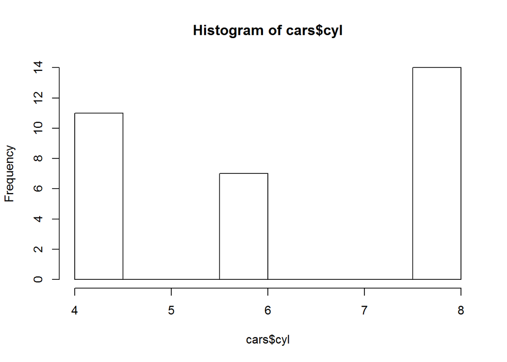

```r
hist(cars$cyl)
```

While this isn’t the prettiest plot, it gets the idea across quickly. Much prettier plotting options will be shown in later tutorials.

### Filtering Data

Getting certain columns from a Data Frame can be helpful but perhaps we need to filter data conditionally for our analysis. Data Frames have built in methods specifically for this purpose. In order to filter by either columns or rows we use square brackets after the variable name. In our case this would be ‘cars[]’. Now, if we think of a Data Frame as a matrix then the indices of the rows and columns are given by [rows,columns]. In the case of our ‘cars’ variable this would be a [32,11] matrix. For instance if we wanted the 3rd column of the 5th row we would type:

```r
cars[5,3]
```

```
## [1] 360
```

We can observe the 5th row to be the Hornet Sportabout, while the 3rd column is disp (engine displacement). The value at this point is 360. Alternatively if wanted all of the columns for the 5th row we simply leave out the 3 and keep the comma as such:

```r
cars[5,]
```

```
##                    mpg cyl disp  hp drat   wt  qsec vs am gear carb
## Hornet Sportabout 18.7   8  360 175 3.15 3.44 17.02  0  0    3    2
```

If we wanted the displacement column we could call it out either by number, name or with the dollar sign notation. Below we show all three methods and you can see the output is the same.

```r
cars[,3]
```

```
##  [1] 160.0 160.0 108.0 258.0 360.0 225.0 360.0 146.7 140.8 167.6 167.6
## [12] 275.8 275.8 275.8 472.0 460.0 440.0  78.7  75.7  71.1 120.1 318.0
## [23] 304.0 350.0 400.0  79.0 120.3  95.1 351.0 145.0 301.0 121.0
```

```r
cars[,"disp"]
```

```
##  [1] 160.0 160.0 108.0 258.0 360.0 225.0 360.0 146.7 140.8 167.6 167.6
## [12] 275.8 275.8 275.8 472.0 460.0 440.0  78.7  75.7  71.1 120.1 318.0
## [23] 304.0 350.0 400.0  79.0 120.3  95.1 351.0 145.0 301.0 121.0
```

```r
cars$disp
```

```
##  [1] 160.0 160.0 108.0 258.0 360.0 225.0 360.0 146.7 140.8 167.6 167.6
## [12] 275.8 275.8 275.8 472.0 460.0 440.0  78.7  75.7  71.1 120.1 318.0
## [23] 304.0 350.0 400.0  79.0 120.3  95.1 351.0 145.0 301.0 121.0
```

If we want more than one column we can include them as an array. For instance

```r
cars[,c("mpg","cyl","disp")]
```

```
##                      mpg cyl  disp
## Mazda RX4           21.0   6 160.0
## Mazda RX4 Wag       21.0   6 160.0
## Datsun 710          22.8   4 108.0
## Hornet 4 Drive      21.4   6 258.0
## Hornet Sportabout   18.7   8 360.0
## Valiant             18.1   6 225.0
## Duster 360          14.3   8 360.0
## Merc 240D           24.4   4 146.7
## Merc 230            22.8   4 140.8
## Merc 280            19.2   6 167.6
## Merc 280C           17.8   6 167.6
## Merc 450SE          16.4   8 275.8
## Merc 450SL          17.3   8 275.8
## Merc 450SLC         15.2   8 275.8
## Cadillac Fleetwood  10.4   8 472.0
## Lincoln Continental 10.4   8 460.0
## Chrysler Imperial   14.7   8 440.0
## Fiat 128            32.4   4  78.7
## Honda Civic         30.4   4  75.7
## Toyota Corolla      33.9   4  71.1
## Toyota Corona       21.5   4 120.1
## Dodge Challenger    15.5   8 318.0
## AMC Javelin         15.2   8 304.0
## Camaro Z28          13.3   8 350.0
## Pontiac Firebird    19.2   8 400.0
## Fiat X1-9           27.3   4  79.0
## Porsche 914-2       26.0   4 120.3
## Lotus Europa        30.4   4  95.1
## Ford Pantera L      15.8   8 351.0
## Ferrari Dino        19.7   6 145.0
## Maserati Bora       15.0   8 301.0
## Volvo 142E          21.4   4 121.0
```

Now conditional filtering messes with this notation as a little bit. We can think of conditional filtering as selecting our rows. This means that if we want all the columns displayed, we need to leave a comma at the end of the filter. We can filter with conditional statements such *equal to* **==**, *greater than* **>** and *less than* **<**. We can also combine these with boolean logic of *and* **&** statements and *or* **|** statements. We can apply these filters to Data Frame columns such as **cars$mpg > 150**. If we wanted to find all the rows where the miles per gallon are above 20 and the displacement are less than 150 we would use:

```r
cars[cars$mpg>20 & cars$disp < 150,]
```

```
##                 mpg cyl  disp  hp drat    wt  qsec vs am gear carb
## Datsun 710     22.8   4 108.0  93 3.85 2.320 18.61  1  1    4    1
## Merc 240D      24.4   4 146.7  62 3.69 3.190 20.00  1  0    4    2
## Merc 230       22.8   4 140.8  95 3.92 3.150 22.90  1  0    4    2
## Fiat 128       32.4   4  78.7  66 4.08 2.200 19.47  1  1    4    1
## Honda Civic    30.4   4  75.7  52 4.93 1.615 18.52  1  1    4    2
## Toyota Corolla 33.9   4  71.1  65 4.22 1.835 19.90  1  1    4    1
## Toyota Corona  21.5   4 120.1  97 3.70 2.465 20.01  1  0    3    1
## Fiat X1-9      27.3   4  79.0  66 4.08 1.935 18.90  1  1    4    1
## Porsche 914-2  26.0   4 120.3  91 4.43 2.140 16.70  0  1    5    2
## Lotus Europa   30.4   4  95.1 113 3.77 1.513 16.90  1  1    5    2
## Volvo 142E     21.4   4 121.0 109 4.11 2.780 18.60  1  1    4    2
```

Note that we need the comma at the entire in order to return all the columns and not cause an error. If we wanted to control the columns that were shown we could add columns to the filter as well. If we wanted to use the same filter as above but only return the mpg and disp columns we would say:

```r
cars[cars$mpg>20 & cars$disp < 150,c("mpg", "disp")]
```

```
##                 mpg  disp
## Datsun 710     22.8 108.0
## Merc 240D      24.4 146.7
## Merc 230       22.8 140.8
## Fiat 128       32.4  78.7
## Honda Civic    30.4  75.7
## Toyota Corolla 33.9  71.1
## Toyota Corona  21.5 120.1
## Fiat X1-9      27.3  79.0
## Porsche 914-2  26.0 120.3
## Lotus Europa   30.4  95.1
## Volvo 142E     21.4 121.0
```

Perhaps we want to keep our filter as a variable and then look at different columns from that.

```r
x <- cars[cars$mpg>20 & cars$disp < 150,]
#show car weights (in thousands of pounds) for the filter
x$wt
```

```
##  [1] 2.320 3.190 3.150 2.200 1.615 1.835 2.465 1.935 2.140 1.513 2.780
```

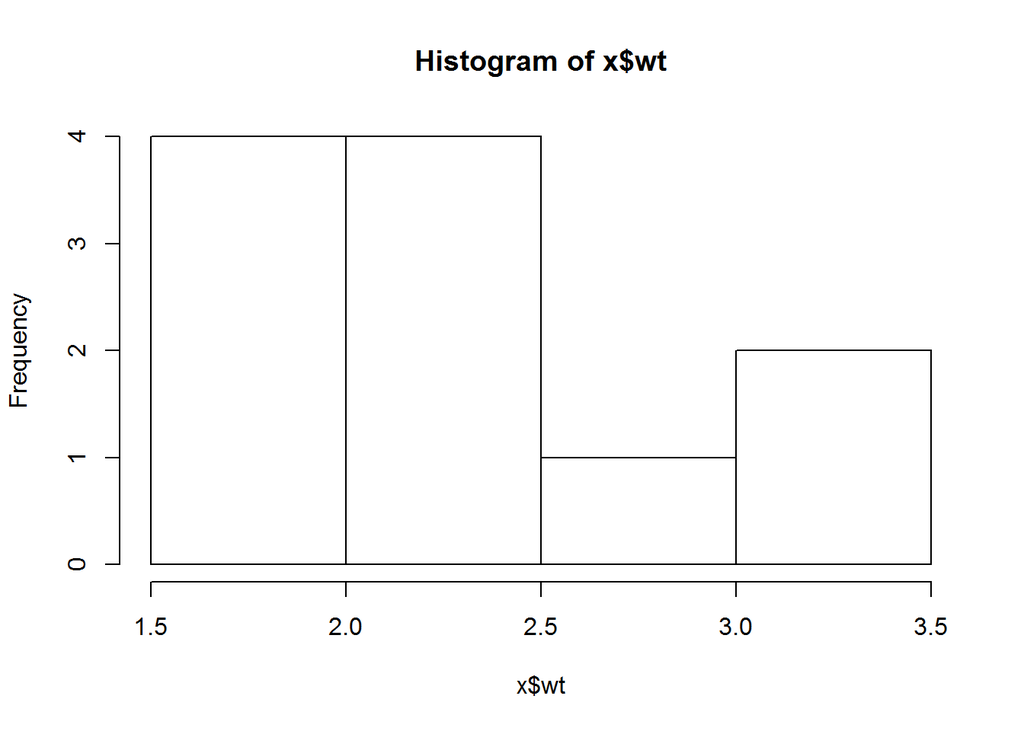

```r
hist(x$wt)
```

### Adding new columns

We can always see what the columns in our Data Frame are named by using the names() function.

```r
names(cars)
```

```
##  [1] "mpg"  "cyl"  "disp" "hp"   "drat" "wt"   "qsec" "vs"   "am"   "gear"
## [11] "carb"
```

But perhaps we want to create a new column. Let’s say we want to create our own column that is the horsepower of the engine divided by the displacement. We think this will give us a good measure of the efficieny of the engine which we would like to plot against mpg.

```r
cars$hpOverDisp <- cars$hp / cars$disp
names(cars)
```

```
##  [1] "mpg"        "cyl"        "disp"       "hp"         "drat"
##  [6] "wt"         "qsec"       "vs"         "am"         "gear"
## [11] "carb"       "hpOverDisp"
```

```r
cars$hpOverDisp
```

```
##  [1] 0.6875 0.6875 0.8611 0.4264 0.4861 0.4667 0.6806 0.4226 0.6747 0.7339
## [11] 0.7339 0.6526 0.6526 0.6526 0.4343 0.4674 0.5227 0.8386 0.6869 0.9142
## [21] 0.8077 0.4717 0.4934 0.7000 0.4375 0.8354 0.7564 1.1882 0.7521 1.2069
## [31] 1.1130 0.9008
```

```r
cars[cars$mpg>20 & cars$disp < 150,"hpOverDisp"] <- 2
cars$hpOverDisp
```

```
##  [1] 0.6875 0.6875 2.0000 0.4264 0.4861 0.4667 0.6806 2.0000 2.0000 0.7339
## [11] 0.7339 0.6526 0.6526 0.6526 0.4343 0.4674 0.5227 2.0000 2.0000 2.0000
## [21] 2.0000 0.4717 0.4934 0.7000 0.4375 2.0000 2.0000 2.0000 0.7521 1.2069
## [31] 1.1130 2.0000
```

Notice the changes? Then as a preview for the next tutorial on plotting I’ll show you how we can very quickly break up data so that we can view the hpOverDisp vs miles per gallon broken up on separate graphs based on cylinder count.

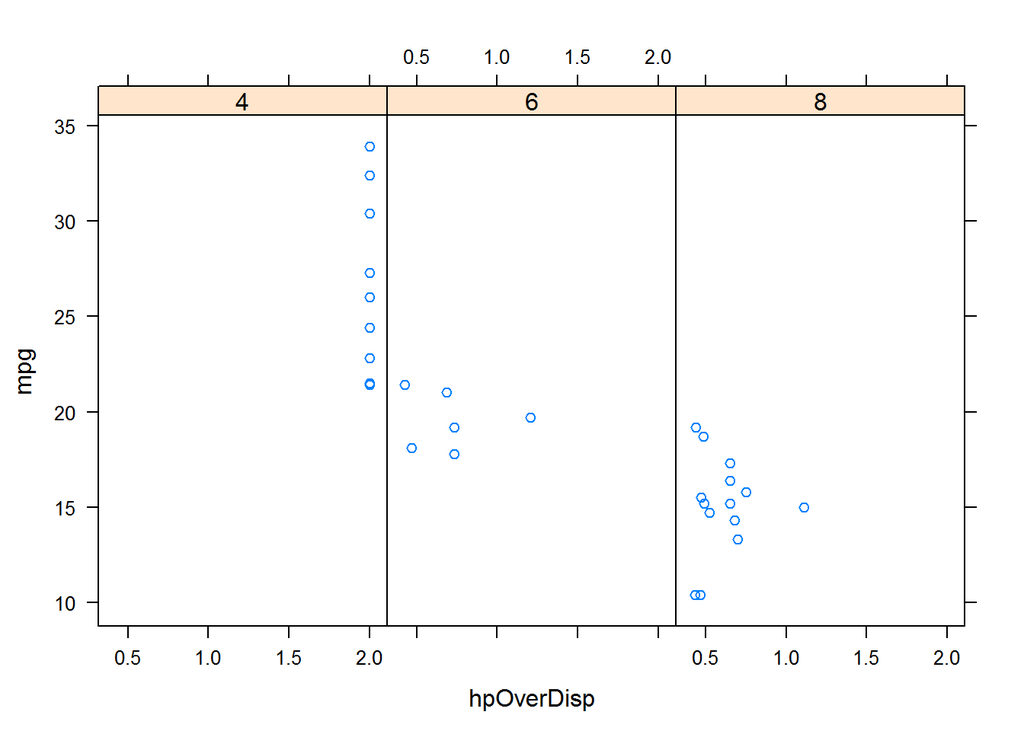

```r
library(lattice)
xyplot(mpg ~ hpOverDisp | factor(cyl), data=cars)
```

The first plot is mpg vs hpOverDisp for all 4 cylinder cars, the second is for 6 cylinder cars and the third is four 8 cylinder cars. It appears that all 4 cylinder cars met our filter of having mpg > 20 and disp < 150 since those are the only values on all plots that have a hpOverDisp equal to 2.